# ⚡ Pokemon Stats 🐲

### 🥊 (Prediction at the end) ✨

### The Brand

Pokémon, (an abbreviation for Pocket Monsters in Japan) is a Japanese media franchise managed by The Pokémon Company, a company founded by Nintendo, Game Freak, and Creatures. The franchise was created by Satoshi Tajiri in 1995, and is centered on fictional creatures called "Pokémon". In Pokémon, humans, known as Pokémon Trainers, catch and train Pokémon to battle other Pokémon for sport. All media works within the franchise are set in the Pokémon universe. The English slogan for the franchise is "Gotta Catch ‘Em All!". There are currently 900 Pokémon species.

| Type Name | Illustration |
| --- | --- |
| **Normal** |  |
| **Fire** |  |
| **Water** |  |
| **Grass** |  |
| **Electric** |  |
| **Ice** |  |
| **Fighting** |  |
| **Poison** |  |
| **Ground** |  |
| **Flying** |  |
| **Psychic** |  |
| **Bug** |  |
| **Rock** |  |
| **Ghost** |  |
| **Dark** |  |
| **Dragon** |  |
| **Steel** |  |
| **Fairy** |  |

These 18 types apply to both Pokémon and their moves. Prior to Generation V, there used to be a ??? type which was only applied to the move Curse before having its typing changed, and the Shadow type, which was only present in Pokémon Colosseum and Pokémon XD: Gale of Darkness.

```python
import numpy as np
import pandas as pd

import matplotlib.pyplot as plt
import seaborn as sns
import plotly.express as px

from sklearn.decomposition import PCA
from sklearn.preprocessing import RobustScaler,StandardScaler,MinMaxScaler
from sklearn.pipeline import make_pipeline

import warnings
warnings.filterwarnings('ignore')
```

```python
data = pd.read_csv('../input/pokemon/pokemon.csv')
df = data.copy()
pd.set_option('display.max_row',df.shape[0])
pd.set_option('display.max_column',df.shape[1])
df.head()
```

|  | abilities | against_bug | against_dark | against_dragon | against_electric | against_fairy | against_fight | against_fire | against_flying | against_ghost | against_grass | against_ground | against_ice | against_normal | against_poison | against_psychic | against_rock | against_steel | against_water | attack | base_egg_steps | base_happiness | base_total | capture_rate | classfication | defense | experience_growth | height_m | hp | … |
| --- | --- | --- | --- | --- | --- | --- | --- | --- | --- | --- | --- | --- | --- | --- | --- | --- | --- | --- | --- | --- | --- | --- | --- | --- | --- | --- | --- | --- | --- | --- |
| 0 | ['Overgrow', 'Chlorophyll'] | 1.0 | 1.0 | 1.0 | 0.5 | 0.5 | 0.5 | 2.0 | 2.0 | 1.0 | 0.25 | 1.0 | 2.0 | 1.0 | 1.0 | 2.0 | 1.0 | 1.0 | 0.5 | 49 | 5120 | 70 | 318 | 45 | Seed Pokémon | 49 | 1059860 | 0.7 | 45 | … |
| 1 | ['Overgrow', 'Chlorophyll'] | 1.0 | 1.0 | 1.0 | 0.5 | 0.5 | 0.5 | 2.0 | 2.0 | 1.0 | 0.25 | 1.0 | 2.0 | 1.0 | 1.0 | 2.0 | 1.0 | 1.0 | 0.5 | 62 | 5120 | 70 | 405 | 45 | Seed Pokémon | 63 | 1059860 | 1.0 | 60 | … |
| 2 | ['Overgrow', 'Chlorophyll'] | 1.0 | 1.0 | 1.0 | 0.5 | 0.5 | 0.5 | 2.0 | 2.0 | 1.0 | 0.25 | 1.0 | 2.0 | 1.0 | 1.0 | 2.0 | 1.0 | 1.0 | 0.5 | 100 | 5120 | 70 | 625 | 45 | Seed Pokémon | 123 | 1059860 | 2.0 | 80 | … |
| 3 | ['Blaze', 'Solar Power'] | 0.5 | 1.0 | 1.0 | 1.0 | 0.5 | 1.0 | 0.5 | 1.0 | 1.0 | 0.50 | 2.0 | 0.5 | 1.0 | 1.0 | 1.0 | 2.0 | 0.5 | 2.0 | 52 | 5120 | 70 | 309 | 45 | Lizard Pokémon | 43 | 1059860 | 0.6 | 39 | … |
| 4 | ['Blaze', 'Solar Power'] | 0.5 | 1.0 | 1.0 | 1.0 | 0.5 | 1.0 | 0.5 | 1.0 | 1.0 | 0.50 | 2.0 | 0.5 | 1.0 | 1.0 | 1.0 | 2.0 | 0.5 | 2.0 | 64 | 5120 | 70 | 405 | 45 | Flame Pokémon | 58 | 1059860 | 1.1 | 58 | … |

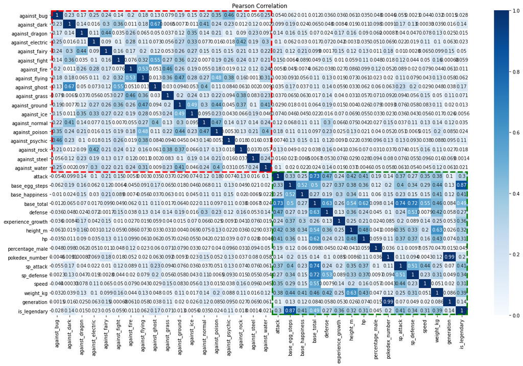

```python
corr = df.corr(method='pearson').abs()

fig = plt.figure(figsize=(20,12))
ax = sns.heatmap(corr, annot=True, cmap='Blues', vmin=0, vmax=+1)

ax.axhline(18,0,18/34, ls='--', linewidth=3, color="red")
ax.axvline(18-0.05,16/34,34/34, ls='--', linewidth=3, color="red")
ax.axhline(0+0.05,0,18/34, ls='--', linewidth=3, color="red")
ax.axvline(0.05,16/34,34/34, ls='--', linewidth=3, color="red")

ax.axhline(18,18/34,34/34, ls='--', linewidth=3, color="green")
ax.axvline(18+0.05,0,16/34, ls='--', linewidth=3, color="green")
ax.axhline(34-0.07,18/34,34/34, ls='--', linewidth=3, color="green")
ax.axvline(34-0.07,0,16/34, ls='--', linewidth=3, color="green")

plt.title('Pearson Correlation')
plt.show()
```

## Comments

- We can see some correlations inside of attack types (red) and other general stats (green)
- We can also see that general stats don't seem to affect the efficiency of attacks against specific types (not framed in green or red)

# Visualizing types

```python
preprocessor = make_pipeline(MinMaxScaler())
numerics = ['int16', 'int32', 'int64', 'float16', 'float32', 'float64']
numeric_df = df.select_dtypes(include=numerics)
numeric_df = numeric_df.fillna(numeric_df.mean())
PCAPipeline = make_pipeline(preprocessor, PCA(n_components=3,random_state=0))
```

```python
df['type1'].unique()
```

```
array(['grass', 'fire', 'water', 'bug', 'normal', 'poison', 'electric',
       'ground', 'fairy', 'fighting', 'psychic', 'rock', 'ghost', 'ice',
       'dragon', 'dark', 'steel', 'flying'], dtype=object)
```

```python
df['type2'].unique()
```

```
array(['poison', nan, 'flying', 'dark', 'electric', 'ice', 'ground',
       'fairy', 'grass', 'fighting', 'psychic', 'steel', 'fire', 'rock',
       'water', 'dragon', 'ghost', 'bug', 'normal'], dtype=object)
```

```python
df['type2'] = df['type2'].fillna('None')
```

```python
PCA_df = pd.DataFrame(PCAPipeline.fit_transform(numeric_df))
PCA_df = pd.concat([PCA_df, df['type1']], axis=1)
PCA_df = pd.concat([PCA_df, df['type2']], axis=1)
PCA_df.head()
```

|  | 0 | 1 | 2 | type1 | type2 |
| --- | --- | --- | --- | --- | --- |
| 0 | -0.669736 | 0.188375 | -0.340281 | grass | poison |
| 1 | -0.576824 | 0.295699 | -0.352801 | grass | poison |
| 2 | -0.328958 | 0.577808 | -0.358374 | grass | poison |
| 3 | -0.686654 | 0.308215 | 0.090032 | fire | None |
| 4 | -0.583342 | 0.427736 | 0.075774 | fire | None |

```python
figure1 = px.scatter_3d(PCA_df,
        x=0,
        y=1,
        z=2,
        color = 'type1',
                       width=600, height=800)
figure1.update_traces(marker=dict(size=5,
                              line=dict(width=0.2,
                                        color='DarkSlateGrey')),
                  selector=dict(mode='markers'))

figure1.show()
```

[interactive chart not shown]

```python
figure2 = px.scatter_3d(PCA_df,
        x=0,
        y=1,
        z=2,
        color = 'type2',
                       width=600, height=800)

figure2.update_traces(marker=dict(size=5,
                              line=dict(width=0.2,
                                        color='DarkSlateGrey')),
                  selector=dict(mode='markers'))
figure2.show()
```

[interactive chart not shown]

# Strength analysis

```python
df=data.copy()
df.head()
```

|  | abilities | against_bug | against_dark | against_dragon | against_electric | against_fairy | against_fight | against_fire | against_flying | against_ghost | against_grass | against_ground | against_ice | against_normal | against_poison | against_psychic | against_rock | against_steel | against_water | attack | base_egg_steps | base_happiness | base_total | capture_rate | classfication | defense | experience_growth | height_m | hp | … |
| --- | --- | --- | --- | --- | --- | --- | --- | --- | --- | --- | --- | --- | --- | --- | --- | --- | --- | --- | --- | --- | --- | --- | --- | --- | --- | --- | --- | --- | --- | --- |
| 0 | ['Overgrow', 'Chlorophyll'] | 1.0 | 1.0 | 1.0 | 0.5 | 0.5 | 0.5 | 2.0 | 2.0 | 1.0 | 0.25 | 1.0 | 2.0 | 1.0 | 1.0 | 2.0 | 1.0 | 1.0 | 0.5 | 49 | 5120 | 70 | 318 | 45 | Seed Pokémon | 49 | 1059860 | 0.7 | 45 | … |
| 1 | ['Overgrow', 'Chlorophyll'] | 1.0 | 1.0 | 1.0 | 0.5 | 0.5 | 0.5 | 2.0 | 2.0 | 1.0 | 0.25 | 1.0 | 2.0 | 1.0 | 1.0 | 2.0 | 1.0 | 1.0 | 0.5 | 62 | 5120 | 70 | 405 | 45 | Seed Pokémon | 63 | 1059860 | 1.0 | 60 | … |
| 2 | ['Overgrow', 'Chlorophyll'] | 1.0 | 1.0 | 1.0 | 0.5 | 0.5 | 0.5 | 2.0 | 2.0 | 1.0 | 0.25 | 1.0 | 2.0 | 1.0 | 1.0 | 2.0 | 1.0 | 1.0 | 0.5 | 100 | 5120 | 70 | 625 | 45 | Seed Pokémon | 123 | 1059860 | 2.0 | 80 | … |
| 3 | ['Blaze', 'Solar Power'] | 0.5 | 1.0 | 1.0 | 1.0 | 0.5 | 1.0 | 0.5 | 1.0 | 1.0 | 0.50 | 2.0 | 0.5 | 1.0 | 1.0 | 1.0 | 2.0 | 0.5 | 2.0 | 52 | 5120 | 70 | 309 | 45 | Lizard Pokémon | 43 | 1059860 | 0.6 | 39 | … |
| 4 | ['Blaze', 'Solar Power'] | 0.5 | 1.0 | 1.0 | 1.0 | 0.5 | 1.0 | 0.5 | 1.0 | 1.0 | 0.50 | 2.0 | 0.5 | 1.0 | 1.0 | 1.0 | 2.0 | 0.5 | 2.0 | 64 | 5120 | 70 | 405 | 45 | Flame Pokémon | 58 | 1059860 | 1.1 | 58 | … |

```python
strength_df = pd.DataFrame()
strength_features = ['against_bug','against_dark','against_dragon','against_electric','against_fairy',
                     'against_fight','against_fire','against_flying','against_ghost','against_grass',
                     'against_ground','against_ice','against_normal','against_poison','against_psychic',
                     'against_rock','against_steel','against_water']
classic_features = ['attack','defense','hp','sp_attack','sp_defense','speed','type1','type2']
strength_df["against_overall"] = df[strength_features].sum(axis=1)
strength_df = pd.concat([df['name'],strength_df,df[classic_features]],axis=1)
strength_df.head()
```

|  | name | against_overall | attack | defense | hp | sp_attack | sp_defense | speed | type1 | type2 |
| --- | --- | --- | --- | --- | --- | --- | --- | --- | --- | --- |
| 0 | Bulbasaur | 19.25 | 49 | 49 | 45 | 65 | 65 | 45 | grass | poison |
| 1 | Ivysaur | 19.25 | 62 | 63 | 60 | 80 | 80 | 60 | grass | poison |
| 2 | Venusaur | 19.25 | 100 | 123 | 80 | 122 | 120 | 80 | grass | poison |
| 3 | Charmander | 18.00 | 52 | 43 | 39 | 60 | 50 | 65 | fire | NaN |
| 4 | Charmeleon | 18.00 | 64 | 58 | 58 | 80 | 65 | 80 | fire | NaN |

```python
strength_df['attack_overall'] = strength_df['attack']+strength_df['sp_attack']
strength_df['defense_overall'] = strength_df['defense']+strength_df['sp_defense']
strength_df.head()
```

|  | name | against_overall | attack | defense | hp | sp_attack | sp_defense | speed | type1 | type2 | attack_overall | defense_overall |
| --- | --- | --- | --- | --- | --- | --- | --- | --- | --- | --- | --- | --- |
| 0 | Bulbasaur | 19.25 | 49 | 49 | 45 | 65 | 65 | 45 | grass | poison | 114 | 114 |
| 1 | Ivysaur | 19.25 | 62 | 63 | 60 | 80 | 80 | 60 | grass | poison | 142 | 143 |
| 2 | Venusaur | 19.25 | 100 | 123 | 80 | 122 | 120 | 80 | grass | poison | 222 | 243 |
| 3 | Charmander | 18.00 | 52 | 43 | 39 | 60 | 50 | 65 | fire | NaN | 112 | 93 |
| 4 | Charmeleon | 18.00 | 64 | 58 | 58 | 80 | 65 | 80 | fire | NaN | 144 | 123 |

```python
figure3 = px.scatter_3d(strength_df,
                        x='attack_overall',
                        y='defense_overall',
                        z='against_overall',
                        color = 'type1',
                        hover_name  = 'name',
                        width=600,
                        height=800)

figure3.update_traces(marker=dict(size=4,
                              line=dict(width=0.2,
                                        color='DarkSlateGrey')),
                  selector=dict(mode='markers'))

figure3.show()
```

[interactive chart not shown]

```python
strongest_df = strength_df[(strength_df['attack_overall']>270) | (strength_df['defense_overall']>290) | (strength_df['against_overall']>23)]
figure4 = px.scatter_3d(strongest_df,
                        x='attack_overall',
                        y='defense_overall',
                        z='against_overall',
                        color = 'type1',
                        hover_name  = 'name',
                        width=600,
                        height=800)

figure4.update_traces(marker=dict(size=4,
                              line=dict(width=0.2,
                                        color='DarkSlateGrey')),
                  selector=dict(mode='markers'))

figure4.show()
```

[interactive chart not shown]

# Conclusion on types strength

#### By looking closely at the scatterplot above, you can tell that a little number of pokemons look way stronger than the others.

#### For instance : **Schuckle** is the most isolated pokemon. He is really week in attack but super strong in defense (can tank a lot) and is globally strong against other types

#### We also have **Legendary pokemons** who are a bit isolated, with really great stats (careful not strong against all types !) :

✨

Mewtwo

Groudon

Kyogre

Latios

#### We can also notice that we have a group of 4 **Rock pokemons** and 3 **Steel pokemons** with **high stats**

[figure not shown]

Bastiodon

Carbink

Probopass

Regirock

[figure not shown]

Aggron

Steelix

Registeel

#### In opposite, we can find **very week pokemons** (mainly **Normal types**) such as :

[figure not shown]

Azurill

Igglybuff

Jigglypuff

#### On the **topline**, we have **bug and rock pokemons** which are really strong against all other types. A little preference for some rock pokemons who have better attack and defense stats (see paragraph above)

#### And at the **bottomline**, we have **Steel pokemon** who are considered the weakest against all other types

# Conclusion

## Play Rock and Bugs (and use Legendaries carefully)